# Grado en Ingenierías en Tecnologías de Telecomunicación

## Asignatura: Tecnologías de Circuito Impreso

### ALUMNO (Apellidos, Nombre): Eduardo Miguel Fernández Díaz

### DNI: 77649094J

### BLOQUES Prof. Andrés Roldán Aranda

### Fecha de entrega: 26/11/24

El alumno rellenará en este mismo fichero las respuesta a las preguntas y podrá añadir las fotografías que necesite a la resolución del problema y sus apartados.

***A*** En el circuito de la figura siguiente:

[figure not shown]

se muestra un conexionado entre varias cargas circuitales muy común entre los alumnos de la titulación. Aunque ahora vamos a ver que es la conexión más ruidosa que podemos encontrar y por eso hay que ***EVITARLA***.

1. Calcular la tensións tensiones que aparecen en los nodos de la pista de retorno a masa y comprobar que coinciden con la imagen anterior.
2. Calcular la tensión a las que está alimentado cada bloque, si en la conexión de alimentación (corrientes entrantes), también existe la misma resistencia que en las conexiones de retorno.

***RESPUESTA***:

***Primer apartado***

Como se puede ver en la imagen anterior, tenemos tres circuitos conectados en serio en la línea de retorno a masa, cada uno con su resistencia de retorno, $R_1$, $R_2$ y $R_3$.

Se trata de una configuración simple pero ruidosa, adecuada solo para señales de baja frecuencia, de menos de 100kHz, y corrientes bajas.

Para obtener las tensiones, vamos a tener en cuenta que las corrientes que fluyen a través de cada circuito se suman conforme avanzamos en serie:

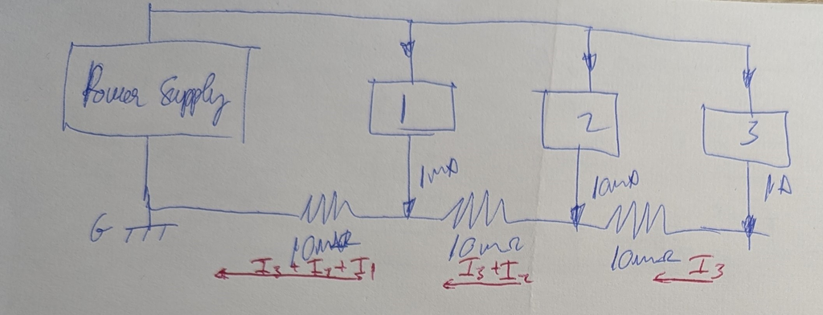

Por ello, la corriente total que pase por $R_1$ será la suma de $I_1 + I_2 + I_3$, la corriente total que pase por $R_2$ será la suma de $I_2 + I_3$, y por último, $R_3$ será la suma de $I_3$.

Por lo tanto:

$V_b1 = (I_1 + I_2 + I_3) · R_1 = 10mV$

Como se puede ver en la siguiente imagen:

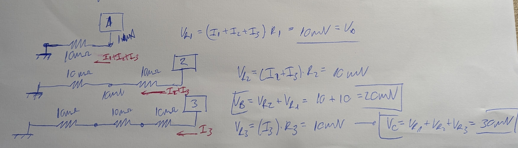

***Segundo apartado***

Para este segundo apartado, suponemos que las resistencias son del mismo valor al anterior. Al no contar con el valor del voltaje que proporciona la fuente, dejaremos la solución en función de este valor:

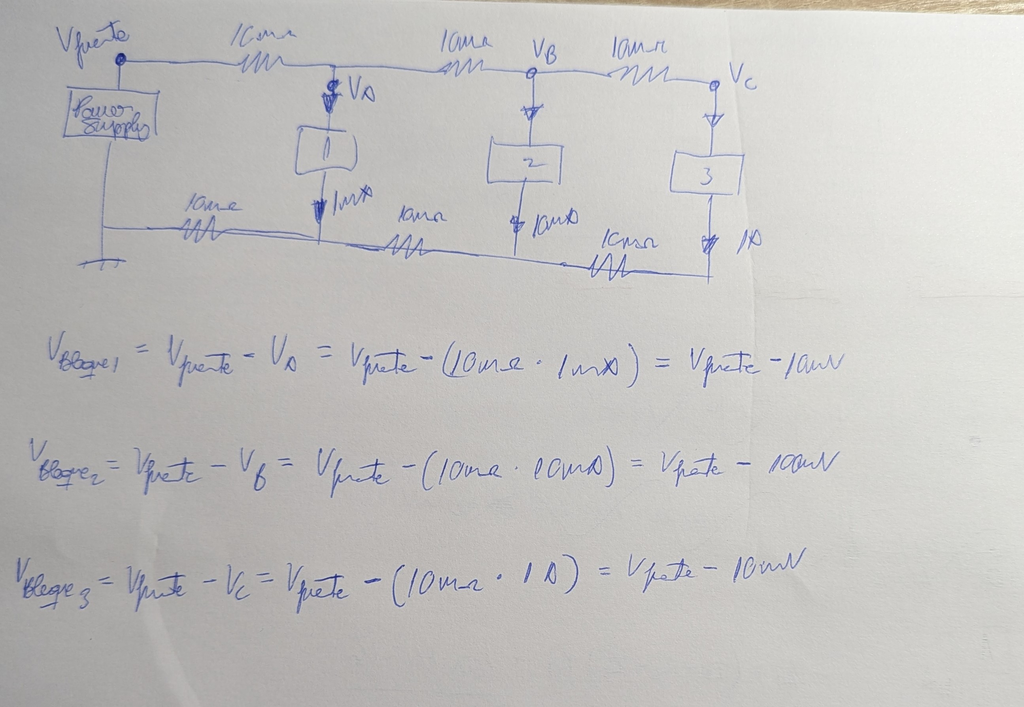

***B*** En el circuito de la figura siguiente:

[figure not shown]

se muestra uno conexionado correcto que solo hacen bien los alumnos que han cursado ***TCI***.

2. Calcular la tensións tensiones que aparecen en los nodos de las pistas de retorno a masa.

***RESPUESTA***:

En este caso, nos encontramos con una configuración mejor que la anterior, pero esta cuenta con muchos cables, lo cual no será bueno para alta frecuencia o circuitos digitales debido a su alta inductancia.

Para resolverlo, seguiremos un procedimiento similar al anterior. En este caso, las corrientes caen directamente sobre las resistencias, y estas van a tierra, por lo que en este caso no tendremos la suma de corrientes, sino una caída de tensión por cada una de las resistencias de cada una de las ramas.

Por lo tanto:

$V_b1 = I_1 · R_1 = 10uV$

$V_b2 = I_2 · R_2 = 200uV$

$V_b3 = I_3 · R_3 = 30mV$

Como se puede ver en la siguiente imagen:

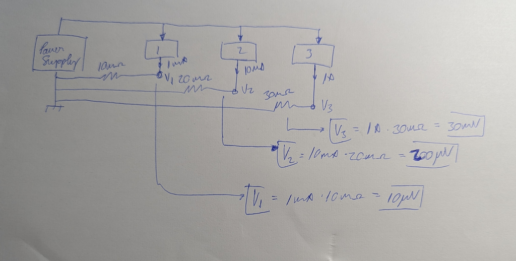

***C*** En el circuito de la figura siguiente:

[figure not shown]

se muestra uno conexionado correcto que haremos en las PCB usando los planos de masa en las capas de *POWER PLANES*.

3. ¿Qué crees que pasará en este conexionado?.

***RESPUESTA***:

Es adecuado para su aplicación en circuitos electrónicos que operan a frecuencias altas, ya que este enfoque reduce la impedancia del conductor de tierra. A medida que aumenta la frecuencia, la impedancia disminuye debido a que los conductores de tierra están conectados en paralelo. Los conductores de tierra deben ser lo más cortos posible y conectarse a un plano de tierra (Ground Plane) o una rejilla de referencia de señal (Signal Reference Grid, SRG). El plano de tierra debe ser delgado para reducir la impedancia a frecuencias altas y mitigar los efectos del Skin Effect (flujo de corriente a través de la superficie del conductor).

***NOTA***:

Para generar el fichero en PDF podemos usar: File -> Export Notebook As -> Html_embeded

Usa la notación de ingeniería en tu cálculos.

...

!pip install engineering_notation # Disponible en: https://github.com/slightlynybbled/engineering_notation

...

**IMPORTANTE** Se adjuntan fotos de los circuitos y las resoluciones que se han colocado durante el documento en la carpeta imagenes, por si fallara al abrir el documento